# hw5

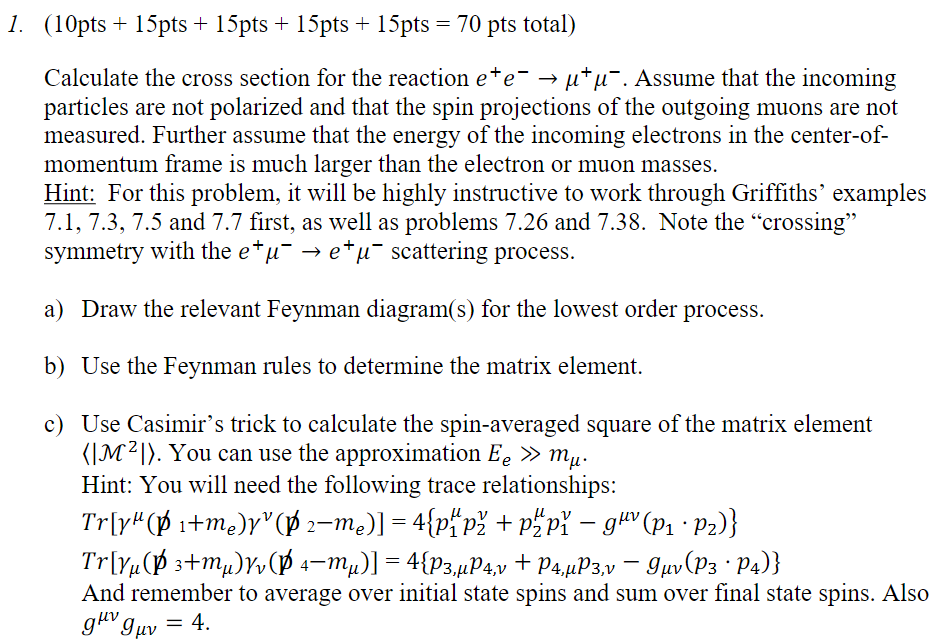

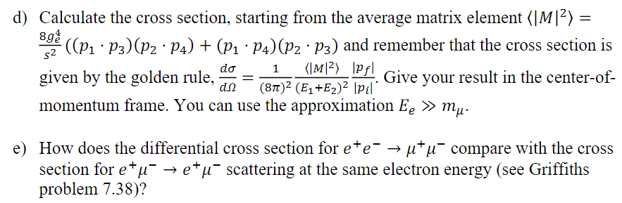

(a)

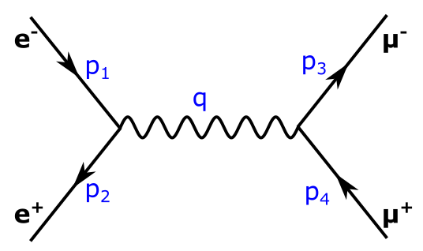

(b) I don't have any packages on this, so I'm using overline instead of strikethrough.

$$ \mathcal{M} = \left[ \bar{v}(p_2)\gamma^\mu u(p_1) \right] \cdot \left( \frac{ie^2}{q^2} \right) \cdot \left[ \bar{u}(p_3)\gamma_\mu v(p_4) \right] $$

(c) Casimir's trick: $$ \langle |\mathcal{M}|^2 \rangle = \frac{1}{4} \sum_{\text{spins}} |\mathcal{M}|^2 $$

Squaring the matrix element yields

$$ |\mathcal{M}|^2 = \left( \frac{e^2}{q^2} \right)^2 \cdot \left[ \bar{v}(p_2)\gamma^\mu u(p_1) \cdot \bar{u}(p_3)\gamma_\mu v(p_4) \right] \cdot \left[ \bar{v}(p_2)\gamma^\nu u(p_1) \cdot \bar{u}(p_3)\gamma_\nu v(p_4) \right]^* $$

Now sum over spins using:

\begin{align*} \sum u(p) \bar{u}(p) &= \gamma^\alpha p_\alpha + m \\ \sum v(p) \bar{v}(p) &= \gamma^\alpha p_\alpha - m \end{align*}

In the relativistic case we aren't so worred about the mass, so we'll drop it. I don't have the \slashed package so I'll just have to write it all out.

$$ \langle |\mathcal{M}|^2 \rangle = \frac{e^4}{q^4} \cdot \frac{1}{4} \cdot \text{Tr}\left[ \gamma^\mu (\gamma^\alpha p_{2\alpha}) \gamma^\nu (\gamma^\beta p_{1\beta}) \right] \cdot \text{Tr}\left[ \gamma_\mu (\gamma^\rho p_{3\rho}) \gamma_\nu (\gamma^\sigma p_{4\sigma}) \right] $$

From the hints:

$$ \text{Tr}\left[ \gamma^\mu \gamma^\alpha \gamma^\nu \gamma^\beta \right] = 4 \left( g^{\mu\alpha}g^{\nu\beta} + g^{\mu\beta}g^{\nu\alpha} - g^{\mu\nu}g^{\alpha\beta} \right) \\ \langle |\mathcal{M}|^2 \rangle = \frac{8 e^4}{q^4} \left[ (p_1 \cdot p_4)(p_2 \cdot p_3) + (p_1 \cdot p_3)(p_2 \cdot p_4) \right] $$

(d) Should simplify pretty well.

$$ s = (p_1 + p_2)^2 \\ t = (p_1 - p_3)^2 \\ u = (p_1 - p_4)^2 = (p_2 - p_3)^2 $$

Since we assume a very small mass, momentum squared goes to zero

$$ (p_i - p_j)^2 = p_i^2 + p_j^2 - 2p_i \cdot p_j \simeq -2p_i \cdot p_j\\ \rightarrow 2p_1 \cdot p_3 = -t \\ \rightarrow 2p_1 \cdot p_4 = -u \\ \rightarrow 2p_2 \cdot p_3 = -u \\ \rightarrow 2p_2 \cdot p_4 = -t \\ $$

This gives us our average

$$ \langle | \mathcal M | ^2 \rangle = \frac{2e^4}{q^4} \left((-u)(-u)+(-t)(-t) \right) = \frac{2e^4}{q^4} \left(u^2 + t^2 \right) $$ Also, google says $q^2 = s$, giving us

$$ \langle | \mathcal M | ^2 \rangle = \frac{2e^4}{s^2} \left(u^2 + t^2 \right) $$

Funilly enough, our approximation also gives us $(E_1 + E_2)^2 = s$, since we drop our mass contributions

$$ \frac{d\sigma}{d\Omega} = \frac{1}{(8\pi)^2} \frac{\langle | \mathcal M | ^2 \rangle}{s} \frac{|\vec p_{out}|}{|\vec p_{in}|} \\ = \frac{2e^4}{(8\pi)^2} \frac{t^2 + u^2}{s^3} $$

Using our work from last time:

$$ t = \frac{s}{2} (\cos \theta - 1) \\ u = -\frac{s}{2}(\cos \theta + 1) \\ $$

This becomes

$$ t^2 + u^2 = \frac{s^2}{2} (\cos^2 \theta +1) \\ \frac{d\sigma}{d\Omega} = \frac{e^4}{(8 \pi)^2 s} \left(1 + \cos^2 \theta\right) $$

Which decreases with input momentum

(e) This is s-channel rather than t-channel, so it peaks once in the $\theta=0-90$, while the scattering process goes to infinity for $\theta =0 $

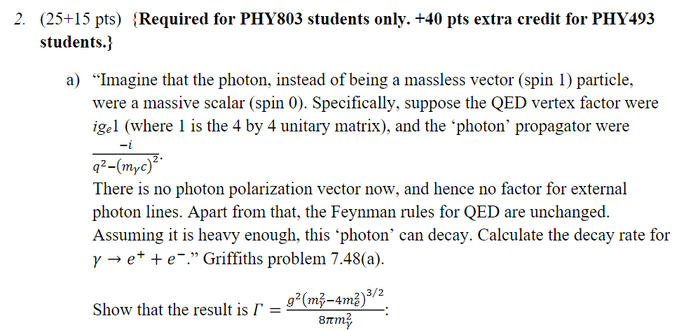

(a) I believe we use $p_{i} = q$? There is only one vertex. We'll average over initial spins (zeo) and sum over final spins

$$ \mathcal M = i g_e \bar u (p_1) v(p_2) \\ \langle | \mathcal M |^2 \rangle = \frac{1}{2} \text{Tr} \left[(\gamma^\mu p_{2,\mu} - m_e)(\gamma^v p_{3,v} + m_e) \right] = 4(p_2 \cdot p_3 - m_e^3) $$

How to deal with the dot product?